# Reproducible Research: Course Assignment 1

CLAM0905

October 28, 2019

# **Course 5 Reproducible Research, Project 1**

This assignment analyzes the amount of steps taken during distinct 5-minute time intervals over the 24 hour day. Variables included in the original dataset are: ** Steps: number of steps taken in a 5 minute interval, with missing values coded as NA Date: The date on which the measurement was taken in YYYY-MM-DD format Interval: Identifier for the 5-minute interval in which measurement was taken **

Below is the analysis on this data:

## Step 1. Loading and preprocessing the data

```r
Activity <- read.csv("C:/Users/klein337/Documents/RProgWork/activity.csv")
Activity$date <- as.Date(Activity$date,"%Y-%m-%d")
View(Activity)
```

## Step 2. What is the mean total number of steps taken per day?

### 2a. Total Number of Steps taken Per day

The following code and table shows the total number of steps taken per day, omitting the NA values:

```r
TotalSteps <- aggregate(steps ~ date, data = Activity, sum, na.action = na.omit)
TotalSteps
```

```
##          date steps
## 1  2012-10-02   126
## 2  2012-10-03 11352
## 3  2012-10-04 12116
## 4  2012-10-05 13294
## 5  2012-10-06 15420
## 6  2012-10-07 11015
## 7  2012-10-09 12811
## 8  2012-10-10  9900
## 9  2012-10-11 10304
## 10 2012-10-12 17382
## 11 2012-10-13 12426
## 12 2012-10-14 15098
## 13 2012-10-15 10139
## 14 2012-10-16 15084
```

[output cut: 39 more lines]

### 2b. Histogram of the total number of steps taken each day

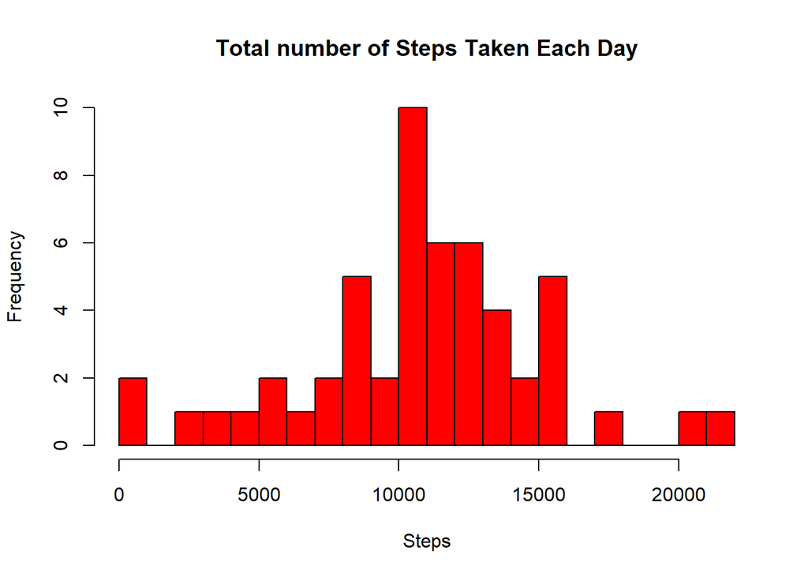

```r
hist(TotalSteps$steps, breaks=30, col="red", xlab="Steps", main="Total number of Steps Taken Each Day")
```

### 2c. Mean and median number of steps taken each day

#### The mean number of steps taken each day is 10766 steps. The below code also includes a table for the mean number of steps taken by day:

```r
meanStepsPerDay <- aggregate(steps ~ date, Activity, mean, na.action = na.omit)
meanStepsPerDay
```

```
##          date      steps
## 1  2012-10-02  0.4375000
## 2  2012-10-03 39.4166667
## 3  2012-10-04 42.0694444
## 4  2012-10-05 46.1597222
## 5  2012-10-06 53.5416667
## 6  2012-10-07 38.2465278
## 7  2012-10-09 44.4826389
## 8  2012-10-10 34.3750000
## 9  2012-10-11 35.7777778
## 10 2012-10-12 60.3541667
## 11 2012-10-13 43.1458333
## 12 2012-10-14 52.4236111
## 13 2012-10-15 35.2048611
## 14 2012-10-16 52.3750000
```

[output cut: 39 more lines]

```r
meanStepsTotal <- mean(TotalSteps$steps)
```

##### The median number of steps taken each day is 10765 steps. The below code also includes a table of the median number of steps taken by day:

```r
medianStepsPerDay <- aggregate(steps ~ date, Activity, median, na.action = na.omit)
medianStepsPerDay
medianStepsTotal <- median(TotalSteps$steps)
```

[output not shown]

## Step3. What is the average daily pattern?

### 3a. Time series plot of the 5-minute interval and average number of steps taken, averaged across all days:

```r
meanStepsPerInterval <- aggregate(steps ~ interval, Activity, mean, na.action = na.omit)
```

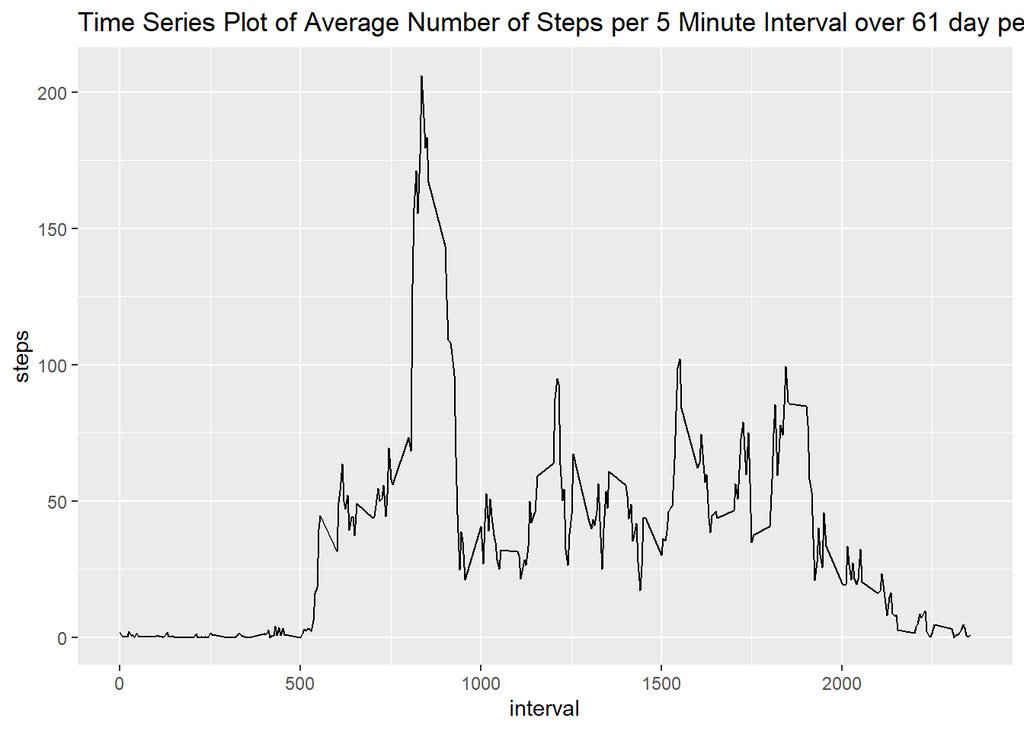

```r
library(ggplot2)
TimeInterval <- ggplot(meanStepsPerInterval, aes(interval, steps)) + geom_line()
print(TimeInterval + ggtitle("Time Series Plot of Average Number of Steps per 5 Minute Interval over 61 day period"))
```

### 3b. Which 5-minute interval that, on average, contains the maximum number of steps

#### The interval that contains the maximum number of steps is interval 835

```r
max(meanStepsPerInterval$steps)
```

```
## [1] 206.1698
```

## 4. Imputing missing values

### 4a. The total number of missing values in dataset are: 2304 Intervals/Rows are missing values, which is 13.1% of dataset

```r
library(imputeTS)
```

```r
statsNA(Activity$steps, bins = 61, printOnly = TRUE)
```

```
## [1] "Length of time series:"
## [1] 17568
## [1] "-------------------------"
## [1] "Number of Missing Values:"
## [1] 2304
## [1] "-------------------------"
## [1] "Percentage of Missing Values:"
## [1] "13.1%"
## [1] "-------------------------"
## [1] "Stats for Bins"
## [1] "  Bin 1 (288 values from 1 to 288) :      288 NAs (100%)"
## [1] "  Bin 2 (288 values from 289 to 576) :      0 NAs (0%)"
## [1] "  Bin 3 (288 values from 577 to 864) :      0 NAs (0%)"
## [1] "  Bin 4 (288 values from 865 to 1152) :      0 NAs (0%)"
## [1] "  Bin 5 (288 values from 1153 to 1440) :      0 NAs (0%)"
```

[output cut: 69 more lines]

#### 4b. Fill NA’s with Mean of the entire day, along with Code to describe and show a strategy for imputing missing data

```r
library(reshape2)
```

```r
ActivityLong <- dcast(Activity, interval ~ date, value.var = "steps") #dcast from long to wide
ActivityLongNA <- na_mean(ActivityLong, option = "mean") #replace NA with mean for the day
ActivityLongNA[is.na(ActivityLongNA)] <- 0 #replace remaining NA with 0, no steps that day
View(ActivityLongNA)
```

#### 4c. Create a new Dataset with the missing values filled in

```r
ActivityWide <- melt(ActivityLongNA, id.vars = c("interval")) #transform back to long data set, next two lines change column name
colnames(ActivityWide)[colnames(ActivityWide)=="variable"] <- "date"
colnames(ActivityWide)[colnames(ActivityWide)=="value"] <- "steps"
View(ActivityWide)
```

#### 4d. Create a Histogram of the total number of steps taken each day after missing values are imputed

```r
TotalStepsAll <- aggregate(steps ~ date, ActivityWide, sum)
TotalStepsAll
```

```
##          date steps
## 1  2012-10-01     0
## 2  2012-10-02   126
## 3  2012-10-03 11352
## 4  2012-10-04 12116
## 5  2012-10-05 13294
## 6  2012-10-06 15420
## 7  2012-10-07 11015
## 8  2012-10-08     0
## 9  2012-10-09 12811
## 10 2012-10-10  9900
## 11 2012-10-11 10304
## 12 2012-10-12 17382
## 13 2012-10-13 12426
## 14 2012-10-14 15098
```

[output cut: 47 more lines]

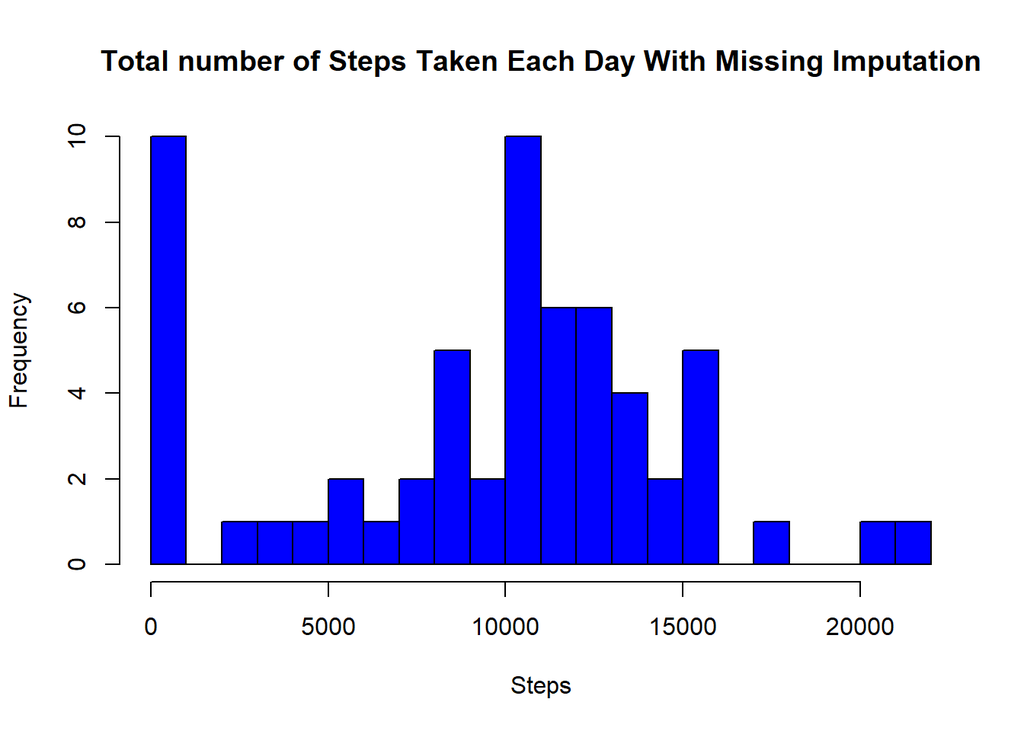

```r
TotalStepsAll$date <- as.Date(TotalStepsAll$date,"%Y-%m-%d")
hist(TotalStepsAll$steps, breaks=30, col="blue", xlab="Steps", main="Total number of Steps Taken Each Day With Missing Imputation")
```

#### 4da. What is the mean total number of steps per day, with no missing data: 9354.23 steps

```r
meanStepsPerDayAll <- aggregate(steps ~ date, ActivityWide, mean, na.action = na.omit)
meanStepsPerDayAll
meanStepsTotalAll <- mean(TotalStepsAll$steps)
meanStepsTotalAll
```

[output not shown]

#### 4db. What is the median total number of steps per day, with no missing data: 10395 steps

```r
medianStepsPerDayAll <- aggregate(steps ~ date, ActivityWide, median, na.action = na.omit)
medianStepsPerDayAll
medianStepsTotalAll <- median(TotalStepsAll$steps)
medianStepsTotalAll
```

[output not shown]

### The mean and medium total number of steps taken per day is lower with the missing values imputed, than when omitted.

## 5. Are there differences in activity patterns between weekdays and weekends?

### 5a. New Factor variable in dataset with two levels- weekday or weekend

```r
ActivityWide2 <- ActivityWide
ActivityWide2$date <- as.Date(ActivityWide$date,"%Y-%m-%d")
ActivityWide2$date <- weekdays(as.Date(ActivityWide$date))
ActivityWide2$WeekDayType <- ifelse(ActivityWide2$date == "Saturday" | ActivityWide2$date ==
                                 "Sunday", "Weekend", "Weekday")
View(ActivityWide2)
```

### 5b. Panel Plot of 5- minute interval and average number of steps taken, averaged across all weekend or weekday days

```r
ActivityWeekend <- subset(ActivityWide2, WeekDayType == "Weekend", select = c("interval", "date", "steps", "WeekDayType"))
ActivityWeekendMean <- ActivityWeekend %>% group_by(interval) %>% mutate(steps.new = mean(steps))
ActivityWeekday <- subset(ActivityWide2, WeekDayType == "Weekday", select = c("interval", "date", "steps", "WeekDayType"))
ActivityWeekdayMean <- ActivityWeekday %>% group_by(interval)  %>% mutate(steps.new = mean(steps))
ActivityAll <- rbind(ActivityWeekendMean, ActivityWeekdayMean)
```

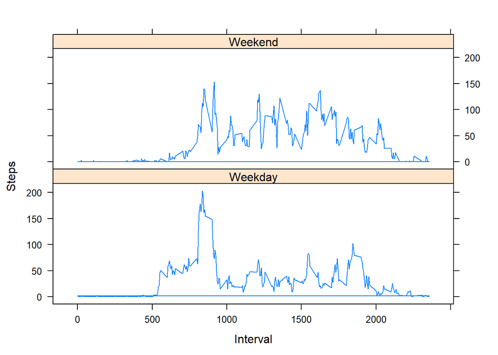

```r
library(lattice)
xyplot(steps.new~interval | WeekDayType, ActivityAll, type = "l", xlab = "Interval", ylab = "Steps", layout=c(1,2))
```